# J3_exploracion_de_datos

## LA PRUEBA DE ANDEVA o ANOVA

En el caso del analisis de varianza normalemnte se presenta una variable numérica de respuesta y una variable categórica con al menos dos niveles o tratamientos como variable explicativa.

#### 1.2 Gráfico de cajas

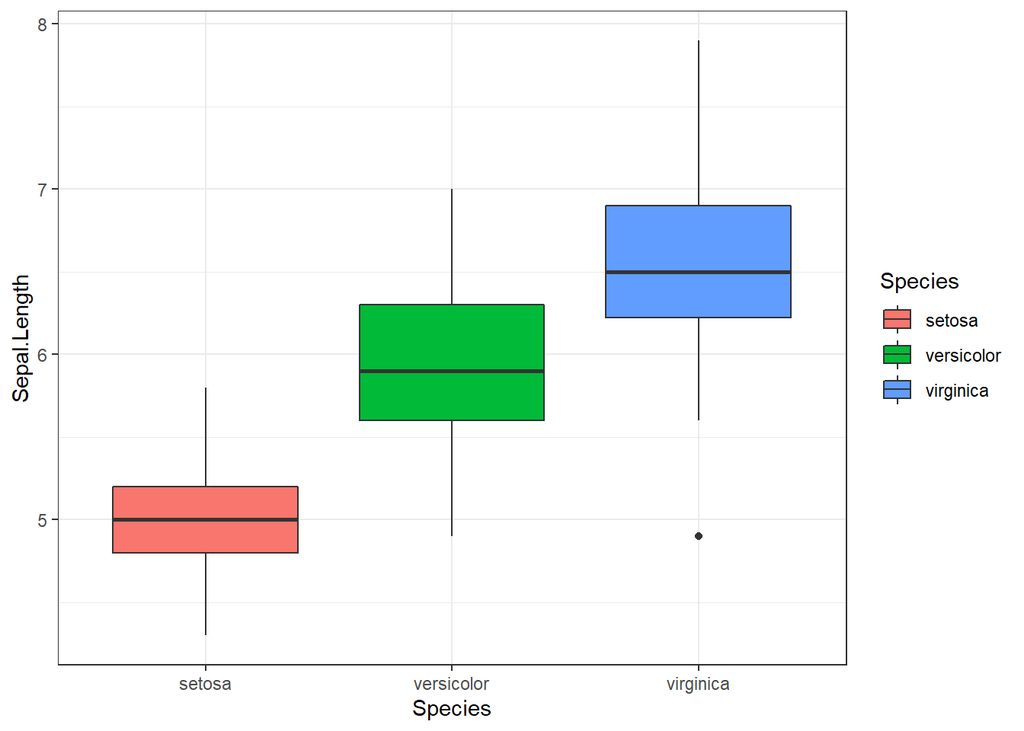

```r
ggplot(iris, aes(y=Sepal.Length, x=Species, fill= Species))+
  geom_boxplot()+
 theme_bw()
```

En el gráfico se observan valores extremos para el grupo virginica

#### 1.3 QQplot

El grafico de cuantil- cuantil (Q-Q) permite examinar normalidad. Aqui se definirá la distribución de los datos en contraste con la distribución normal teórica que se representa por la linea recta.

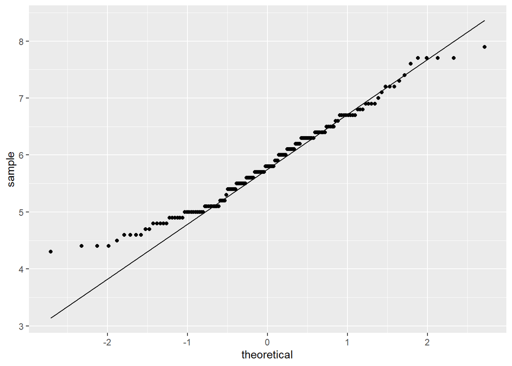

```r
ggplot(iris, aes(sample = iris$Sepal.Length))+
  stat_qq() +
  stat_qq_line()
```

El gráfico cuantil cuantil revela cierta desviación de la normalidad en los extremos superior e inferior del gráfico.

#### 2. Pruebas de normalidad considerando técnicas numéricas

Las pruebas de normalidad numéricas son un cuanto estrictas y menos preferidas, especialmente porque un ANDEVA con un tamaño de muestra mayor a 30 es bastante robusto a pequeñas desvaciones de normalidad.

#### PRUEBA DE NORMALIDAD: SHAPIRO-WILK Y KOLMOGORV-SMIRNOV

##### Prueba Shapiro-Wilk de normalidad para la longitud de los sépalos global y por especie

```r
shapiro.test(iris$Sepal.Length)
```

```
##
##  Shapiro-Wilk normality test
##
## data:  iris$Sepal.Length
## W = 0.97609, p-value = 0.01018
```

```r
shapiro.test(iris$Sepal.Length[iris$Species=="virginica"])
```

```
##
##  Shapiro-Wilk normality test
##
## data:  iris$Sepal.Length[iris$Species == "virginica"]
## W = 0.97118, p-value = 0.2583
```

```r
shapiro.test(iris$Sepal.Length[iris$Species=="setosa"])
```

```
##
##  Shapiro-Wilk normality test
##
## data:  iris$Sepal.Length[iris$Species == "setosa"]
## W = 0.9777, p-value = 0.4595
```

```r
shapiro.test(iris$Sepal.Length[iris$Species=="versicolor"])
```

```
##
##  Shapiro-Wilk normality test
##
## data:  iris$Sepal.Length[iris$Species == "versicolor"]
## W = 0.97784, p-value = 0.4647
```

##### 2.1.2 prubea Kolmogorov Smirnov de normalidad para la longitud de los sépalos global y por especie

```r
ks.test(iris$Sepal.Length, "pnorm")
```

```
##
##  One-sample Kolmogorov-Smirnov test
##
## data:  iris$Sepal.Length
## D = 0.99999, p-value < 2.2e-16
## alternative hypothesis: two-sided
```

```r
ks.test(iris$Sepal.Length[iris$Species=="setosa"], "pnorm")
```

```
##
##  One-sample Kolmogorov-Smirnov test
##
## data:  iris$Sepal.Length[iris$Species == "setosa"]
## D = 0.99999, p-value < 2.2e-16
## alternative hypothesis: two-sided
```

```r
ks.test(iris$Sepal.Length[iris$Species=="versicolor"], "pnorm")
```

```
##
##  One-sample Kolmogorov-Smirnov test
##
## data:  iris$Sepal.Length[iris$Species == "versicolor"]
## D = 1, p-value < 2.2e-16
## alternative hypothesis: two-sided
```

```r
ks.test(iris$Sepal.Length[iris$Species=="virginica"], "pnorm")
```

```
##
##  One-sample Kolmogorov-Smirnov test
##
## data:  iris$Sepal.Length[iris$Species == "virginica"]
## D = 1, p-value < 2.2e-16
## alternative hypothesis: two-sided
```

Hay una diferencia entre las pruebas. Cuál podriamos confiar…..

### 3. Prueba de HOMEGENEIDAD DE VARIANZA en R para la longitud de los sépalos global y por especie

En este caso se utilizará la prueba de Levene:

##### Prueba de Levene

```r
leveneTest(Sepal.Length ~ Species, data = iris)
```

```
## Levene's Test for Homogeneity of Variance (center = median)
##        Df F value   Pr(>F)
## group   2  6.3527 0.002259 **
##       147
## ---
## Signif. codes:  0 '***' 0.001 '**' 0.01 '*' 0.05 '.' 0.1 ' ' 1
```

Al examinar las varianzas entre los grupos, la prueba de Levene identifica que las varianzas entre especies no son similares, sugiriendo una violación a este supuesto.

##### 3.1.1 Prueba de Fligner

```r
fligner.test(Sepal.Length ~ Species, data = iris)
```

```
##
##  Fligner-Killeen test of homogeneity of variances
##
## data:  Sepal.Length by Species
## Fligner-Killeen:med chi-squared = 11.618, df = 2, p-value = 0.003
```

Al examinar las varianzas entre los grupos, la prueba de Fligner identifica que las varianzas entre especies no son similares, sugiriendo una violación a este supuesto.

##### 3.1.2 Gráfico de distribución de residuales para analizar la homogeneidad de varianza

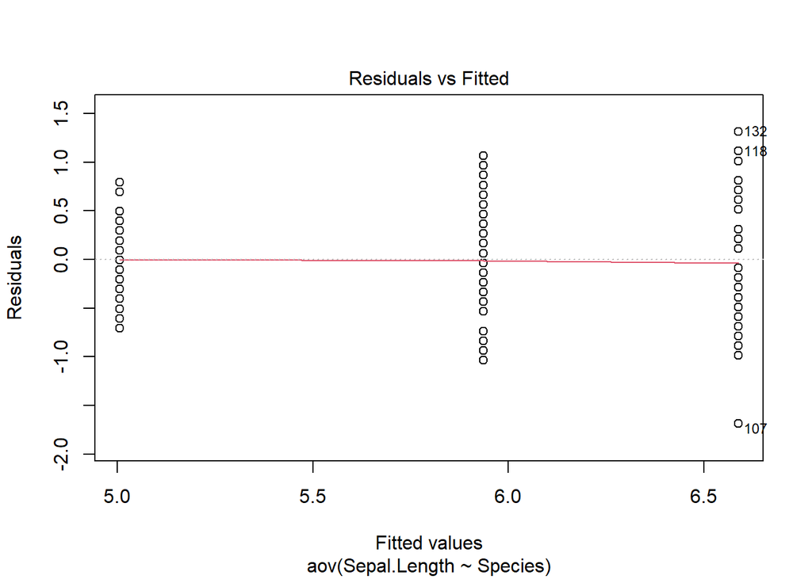

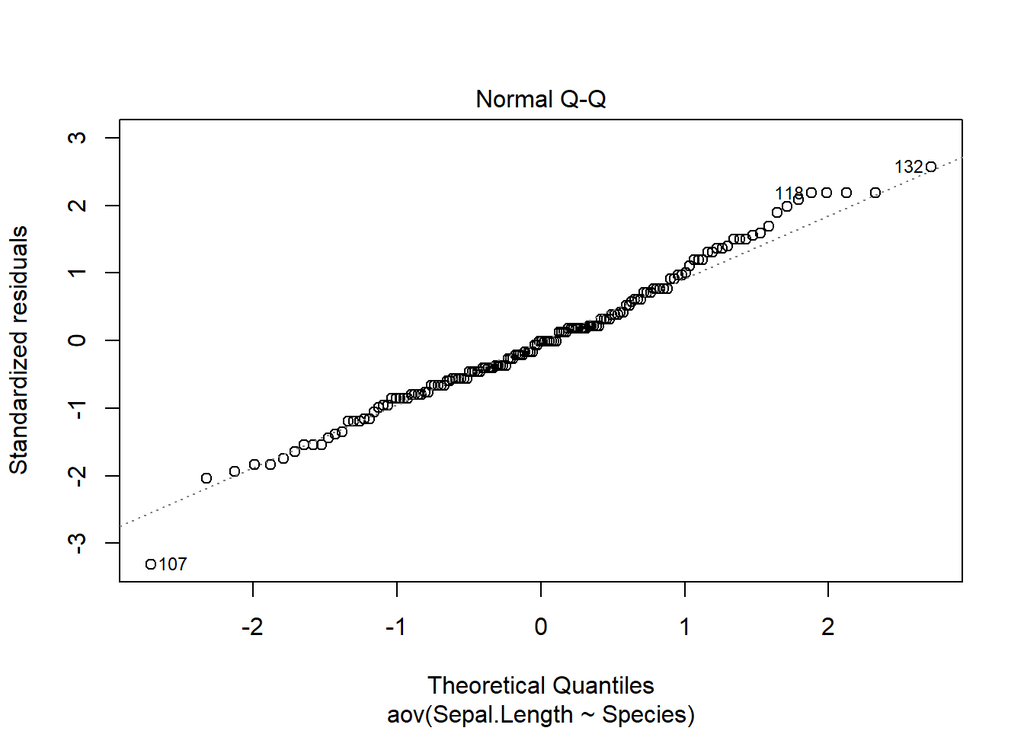

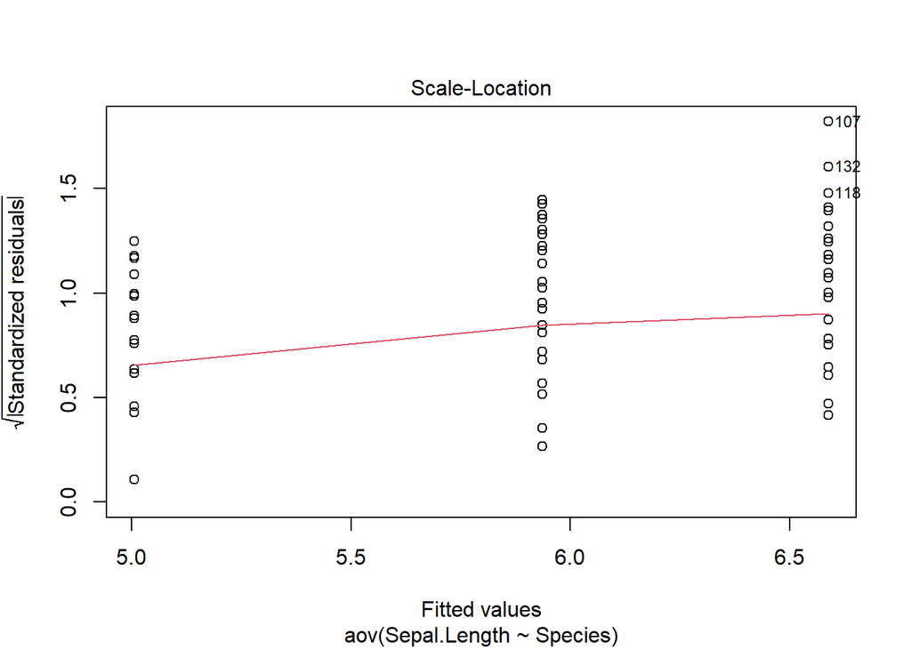

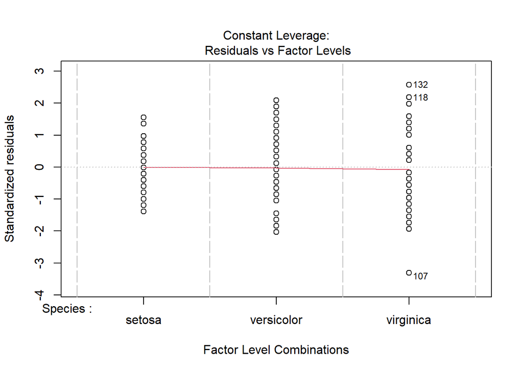

```r
plot(aov(Sepal.Length~Species, data=iris))
```

Observamos 3 lineas verticales que corresponde a los tres grupos para la variable specie. Los valores de los residuales graficados contra los valores ajustados indican que las lineas tienen rangos diferentes y que la varianza entre grupos difiere, sin embargo estas desviaciones son mínimas.

### Análisis de varianza (ANDEVA, ANOVA)

#### Análisis de varianza (ANDEVA, ANOVA) para la longitud de los sépalos entre species en R.

El Análisis de varianza (ANDEVA, ANOVA), es un método para comparar dos o más medias o promedios, que es necesario porque cuando se quiere comparar más de dos medias es incorrecto utilizar repetidamente el contraste basado en la prueba t de Student por dos motivos:

En primer lugar, y como se realizarían simultánea e independientemente varios contrastes de hipótesis, la probabilidad de encontrar alguno significativo por azar aumentaría.

Por otro lado, en cada comparación la hipótesis nula es que las dos muestras provienen de la misma población, por lo tanto, cuando se hayan realizado todas las comparaciones, la hipótesis nula es que todas las muestras provienen de la misma población y, sin embargo, para cada comparación, la estimación de la varianza necesaria para el contraste es distinta, pues se ha hecho en base a muestras distintas.

El código base para ejecutar el análisis en R es aov que se refiere a Análisis de Varianza. Para el análisis se necesita una variable respuesta, continua o discreta, númerica y una variable categórica o factor con dos o más niveles.

En este caso la hipótesis a probar es:

1. H0: No hay diferencia entre las medias de los grupos y la HI: La media de al menos un grupo es diferente.

```r
aovsepalos<-aov(Sepal.Length~Species, data=iris)
summary(aovsepalos)
```

```
##              Df Sum Sq Mean Sq F value Pr(>F)
## Species       2  63.21  31.606   119.3 <2e-16 ***
## Residuals   147  38.96   0.265
## ---
## Signif. codes:  0 '***' 0.001 '**' 0.01 '*' 0.05 '.' 0.1 ' ' 1
```

Como interpretar estos resultados….

Df corresponde a los grados de libertad (degrees of freedom), para el caso 2 es el resultado del número de grupos (Species) menos 1 (3-1=2)

Para el segundo caso, los grados de libertad corresponden a el número total de muestras (150) menos el número de grupos en compración (3), entonces 150-3=147

Mean Sq= Mean Sq/df= 63.21/2 Mean Sq= Mean Sq/df= 38.96/147

```r
63.21/2
```

```
## [1] 31.605
```

```r
31.606/0.265
```

```
## [1] 119.2679
```

Un valor de F que sea substancialmente mayor que 1 sugiere que la variable categórica a prueba explica en gran medida la variabilidad en los datos, más que si no hubiese una variable utilizada para explicar el fenómeno. Como consequencia las diferencias entre las observaiones pueden ser explicadas en gran medida debido a las diferencias en tratamientos mas que a una variación aleatoria.

Cuando la probailidad de observar un valor the F igual o más extremo que el obtenido es menor que un valor partiuclar de alfa, que usualmente es menor a 0.05 o 0.01, asumimos que es poco probable que las muestras colectadas no sean afectadas por el tratamiento en cuestion, por lo tanto rechazamos la hipotesis nula y aceptamos la hipótesis de investigación.

Ahora que sabemos que la media de al menos un grupo es diferente, procedemos a realizar un análisis más específico para determinar entre cuáles grupos existen esas diferencias. El método para realizar esta comparación es usualmente la prueba de Difererencias Honestamente significativas de Tukey (Tukey’s Honestly Significant Difference (Tukey’s HSD). Recuerden que un valor inferior a 0.05 (p<0.05) representa differencias significativas entre grupos.

#### POST HOC Análisis y comparaciones no dirigidas

```r
TukeyHSD(aovsepalos, conf.level=0.95)
```

[output not shown]

El resultado nos indica que cada grupo es diferente entre si. Este resultado se puede observar de forma gráfica asi:

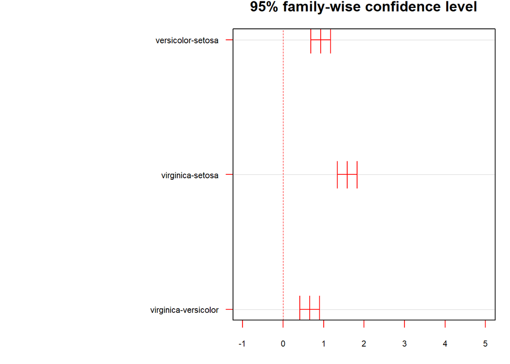

```r
par(mar=c(3,16,2,1))
plot(TukeyHSD(aovsepalos,conf.level=0.95,),col="red",las=1, cex.axis=0.7, xlim = c(-1,5), )
```

En este caso la función indica:

**par(mar=c(3,16,2,1))**: la función “**par**” que es usada para ajustar parámetros del gráfico. En este caso se refiere a los margenes e incluye un vector con los datos para el fondo, lado izquierdo, parte superior y lado derecho para cada lado del area del gráfico. Usualmente los valores estan ajustados como c(5, 4, 4, 2).

**plot(TukeyHSD(aovpetalos,conf.level=0.95),las=1, cex.axis=0.7, xlim = c(-1,5))**: Genera un gráfico con el resultado de la prueba de Tukey (Tukey’s HSD test). Usualmente utiliza 0.95 pero pude cambiarse a 0.99 (Intentalo). La función **las** se refiere a la orientación de las vinetas en el gráfico.0: es paralelo al eje [por defecto], 1: horizontal, 2: perpendicular al eje, 3: vertical. The última parte, cex.axis=0.7 ajusta el tamaño de la fuente con relación al gráfico. Xlim= c(-1,5) indica el ámbito para el eje x en el gráfico, en este caso desde -1 a 5

## REGRESION LINENAL SIMPLE

La regresión lineal simple consiste en generar un modelo de regresión (ecuación de una recta) que permita explicar la relación lineal que existe entre dos variables. A la variable dependiente o respuesta se le identifica como Y y a la variable predictora o independiente como X.

La prueba de significancia para la pendiente (β1) del modelo lineal considera como hipótesis: H0: No hay relación lineal entre ambas variables por lo que la pendiente del modelo lineal es cero. β1=0 Ha: Sí hay relación lineal entre ambas variables por lo que la pendiente del modelo lineal es distinta de cero. β1≠0

### SUPUESTOS DE LA REGRESION LINEAL SIMPLE

1. Linealidad: La relación entre ambas variables debe ser lineal.
2. Distribución Normal de los residuos: Los residuos se tiene que distribuir de forma normal, con media igual a 0.
3. Varianza de residuos constante (homocedasticidad): La varianza de los residuos ha de ser aproximadamente constante a lo largo del eje x
4. Valores atípicos y de alta influencia: Hay que estudiar con detenimiento los valores atípicos o extremos ya que pueden generar una falsa correlación que realmente no existe, u ocultar una existente.
5. Independencia, Autocorrelación: Las observaciones deben ser independientes unas de otras. Esto es importante tenerlo en cuenta cuando se trata de mediciones temporales.

Debido a que los supuestos se validan a partir de los residuos, primero se suele generar el modelo y después se validarlo por medio de los residuos. Este es un proceso iterativo iterativo en el que se ajusta un modelo inicial, se evalúa mediante sus residuos y se mejora.

**PARA ESTE EJEMPLO SE UTILIZARA LA BASE QUE HEMOS CREADO iris_no_setosa, que excluye la especie setosa la cuál es particularmente diferente**.

```r
head(iris_no_setosa)
```

```
##   Sepal.Length Sepal.Width Petal.Length Petal.Width    Species
## 1          7.0         3.2          4.7         1.4 versicolor
## 2          6.4         3.2          4.5         1.5 versicolor
## 3          6.9         3.1          4.9         1.5 versicolor
## 4          5.5         2.3          4.0         1.3 versicolor
## 5          6.5         2.8          4.6         1.5 versicolor
## 6          5.7         2.8          4.5         1.3 versicolor
```

### Observacion y detección de la tendencias

La forma mas fácil de detectar tendencias es por medio de gráficos (analisis exploratorios).

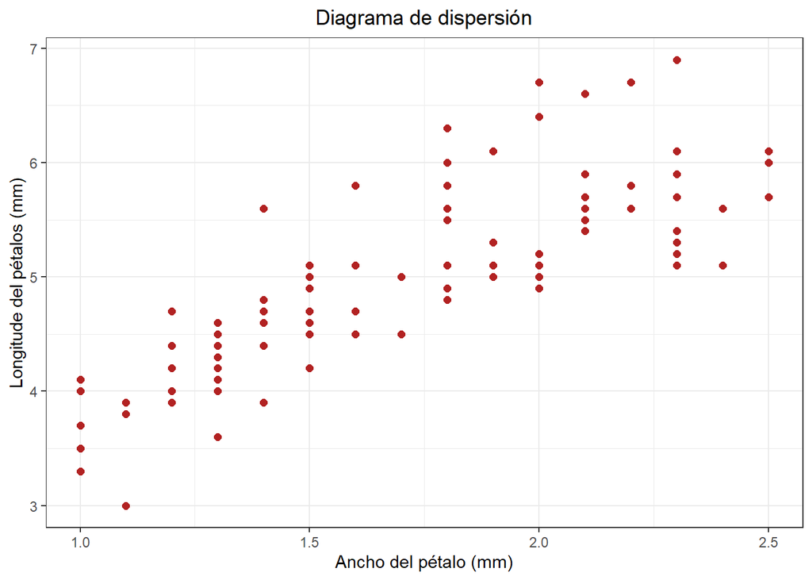

```r
ggplot(data = iris_no_setosa, mapping = aes(x = Petal.Width, y = Petal.Length)) +
  geom_point(color = "firebrick", size = 2) +
  labs(title  =  'Diagrama de dispersión', x  =  'Ancho del pétalo (mm)', y="Longitude del pétalos (mm)") +
  theme_bw() +
  theme(plot.title = element_text(hjust = 0.5))
```

La forma númerica de hacerlo, es con un análisis de correlación

```r
cor.test(x = iris_no_setosa$Petal.Length, y = iris_no_setosa$Petal.Width, method = "pearson")
```

```
##
##  Pearson's product-moment correlation
##
## data:  iris_no_setosa$Petal.Length and iris_no_setosa$Petal.Width
## t = 14.362, df = 98, p-value < 2.2e-16
## alternative hypothesis: true correlation is not equal to 0
## 95 percent confidence interval:
##  0.7478763 0.8778065
## sample estimates:
##       cor
## 0.8233476
```

Parece que existe una relación lineal entre las variables, ejecutemos el modelo.

```r
lm_pet_sep <- lm(Petal.Length ~ Petal.Width, data=iris_no_setosa)
# lm() devuelve el valor de la variable y para x=0 (intersección) junto
# con la pendiente de la recta.
# Para ver la información del modelo se requiere summary().
summary(lm_pet_sep)
```

```
##
## Call:
## lm(formula = Petal.Length ~ Petal.Width, data = iris_no_setosa)
##
## Residuals:
##     Min      1Q  Median      3Q     Max
## -0.9842 -0.3043 -0.1043  0.2407  1.2755
##
## Coefficients:
##             Estimate Std. Error t value Pr(>|t|)
## (Intercept)   2.2240     0.1926   11.55   <2e-16 ***
## Petal.Width   1.6003     0.1114   14.36   <2e-16 ***
## ---
## Signif. codes:  0 '***' 0.001 '**' 0.01 '*' 0.05 '.' 0.1 ' ' 1
##
## Residual standard error: 0.4709 on 98 degrees of freedom
## Multiple R-squared:  0.6779, Adjusted R-squared:  0.6746
## F-statistic: 206.3 on 1 and 98 DF,  p-value: < 2.2e-16
```

La primera columna (Estimate) devuelve el valor estimado para los dos parámetros de la ecuación del modelo lineal (β0^ y β1^) que equivalen a la ordenada en el origen y la pendiente.

Se muestran los errores estándar, el valor del estadístico t y el p-value (dos colas) de cada uno de los dos parámetros. Esto permite determinar si los parámetros son significativamente distintos de 0, es decir, que tienen importancia en el modelo. En los modelos de regresión lineal simple, el parámetro más informativo suele ser la pendiente.

Para el modelo generado, tanto la ordenada en el origen como la pendiente son significativas (p-values < 0.05).

El p-value obtenido en el test F (< 2.2e-16) determina que sí es significativamente superior la varianza explicada por el modelo en comparación a la varianza total. Es el parámetro que determina si el modelo es significativo y por lo tanto se puede aceptar la aplicacion de este modelo.

El modelo lineal generado sigue la ecuación Petal.Length = 2.2240 + 1.6003 Petal.Width. Por cada unidad que se incrementa el el ancho del petalo, la longitud del petalo aumenta en promedio de.1.6003 unidades.

### Intervalos de confianza en el Modelo

```r
confint(lm_pet_sep)
```

```
##                2.5 %   97.5 %
## (Intercept) 1.841770 2.606174
## Petal.Width 1.379134 1.821377
```

#### El grafico…la fotografia de nuestro modelo

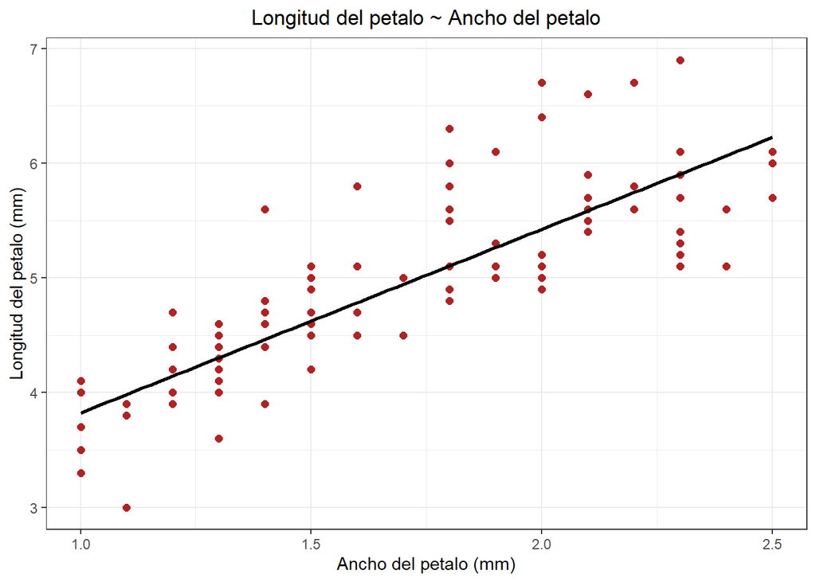

```r
ggplot(data = iris_no_setosa, mapping = aes(x = Petal.Width, y = Petal.Length)) +
  geom_point(color = "firebrick", size = 2) +
  labs(title  =  'Longitud del petalo ~ Ancho del petalo', x  =  'Ancho del petalo (mm)', y="Longitud del petalo (mm)")+
  geom_smooth(method = "lm", se = FALSE, color = "black") +
  theme_bw() +
  theme(plot.title = element_text(hjust = 0.5))
```

Además de la línea de mínimos cuadrados es recomendable incluir los límites superior e inferior del intervalo de confianza. Esto permite identificar la región en la que, según el modelo generado y para un determinado nivel de confianza, se encuentra el valor promedio de la variable dependiente.

Para poder representar el intervalo de confianza a lo largo de todo el modelo se recurre a la función predict() para predecir valores que abarquen todo el eje X. Se añaden al gráfico líneas formadas por los límites superiores e inferiores calculados para cada predicción.

```r
# Se genera una secuencia de valores x_i que abarquen todo el rango de las  observaciones de la variable X
intervalo <- seq(from = min(iris_no_setosa$Petal.Width),
              to = max(iris_no_setosa$Petal.Length),
              length.out = 100)
# Se predice el valor de la variable Y junto con su intervalo de confianza para cada uno de los puntos generados. En la función predict() hay que nombrar a los nuevos puntos con el mismo nombre que la variable X del modelo.

# Devuelve una matriz.
limites_intervalo <- predict(object = lm_pet_sep,
                             newdata = data.frame(Petal.Width = intervalo),
                             interval = "confidence", level = 0.95)
head(limites_intervalo, 3)# 3 este caso indica que solo queremos ver los primeros tres valores, en realidad hay 100 aqui
```

```
##        fit      lwr      upr
## 1 3.824227 3.647939 4.000516
## 2 3.919596 3.754334 4.084858
## 3 4.014965 3.860392 4.169538
```

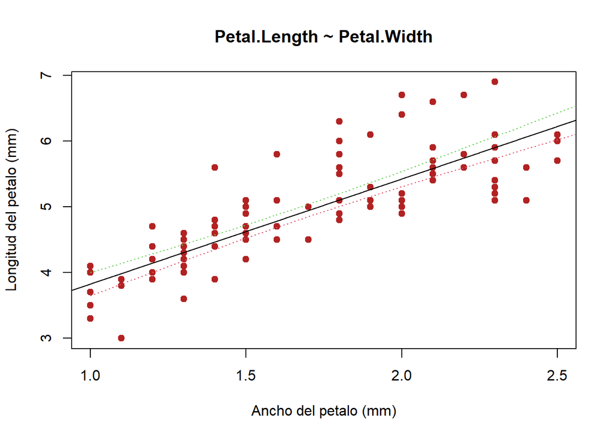

```r
# Finalmente se añaden al gráfico las líneas formadas por los límites superior e inferior.
plot(iris_no_setosa$Petal.Width, iris_no_setosa$Petal.Length, col = "firebrick", pch = 19, ylab = "Longitud del petalo (mm)",
     xlab = "Ancho del petalo (mm)", main = 'Petal.Length ~ Petal.Width')
abline(lm_pet_sep, col = 1)
lines(x = intervalo, y = limites_intervalo[,2],type = "l", col = 2, lty = 3)
lines(x = intervalo, y = limites_intervalo[,3],type = "l", col = 3, lty = 3)
```

La función geom_smooth() del paquete ggplot2 genera la regresión y su intervalo de forma directa, ahorrandonos los paso anteriores

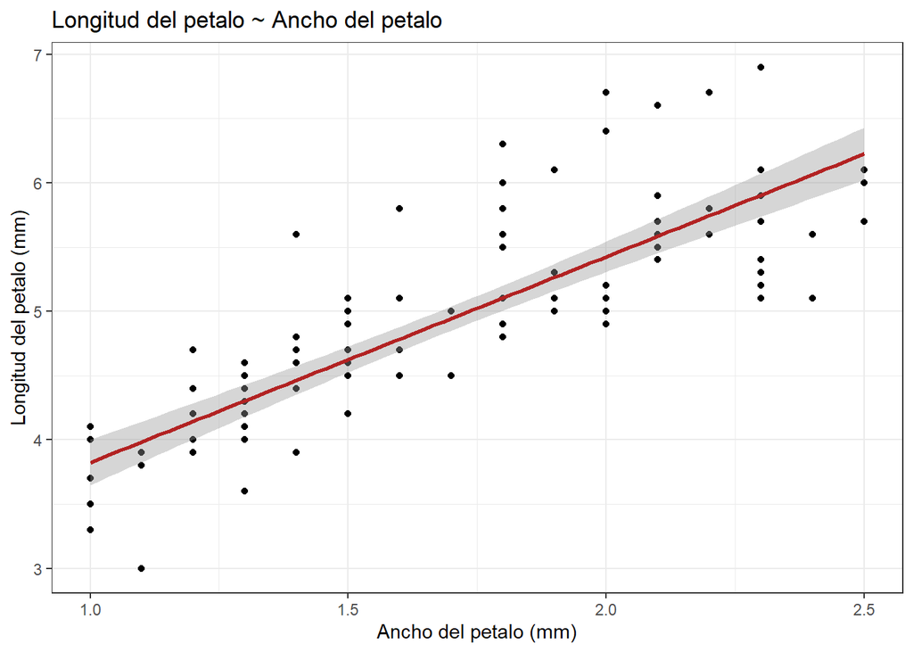

```r
ggplot(data = iris_no_setosa, aes(x = Petal.Width, y = Petal.Length)) +
  geom_point() +
  labs(title  =  'Longitud del petalo ~ Ancho del petalo', x  =  'Ancho del petalo (mm)', y="Longitud del petalo (mm)")+
  geom_smooth(method = "lm", se = TRUE, color = "firebrick") +
  theme_bw()
```

# Validacion del modelo, analisis y verificacion de los supuestos

1. Linealidad: La relación entre ambas variables debe ser lineal.
2. Distribución Normal de los residuos: Los residuos se tiene que distribuir de forma normal, con media igual a 0.
3. Varianza de residuos constante (homocedasticidad): La varianza de los residuos ha de ser aproximadamente constante a lo largo del eje x
4. Valores atípicos y de alta influencia: Hay que estudiar con detenimiento los valores atípicos o extremos ya que pueden generar una falsa correlación que realmente no existe, u ocultar una existente.
5. Independencia, Autocorrelación: Las observaciones deben ser independientes unas de otras. Esto es importante tenerlo en cuenta cuando se trata de mediciones temporales.
6. Linealidad: La relación entre ambas variables debe ser lineal.

```r
# La función lm() calcula y almacena los valores predichos por el modelo y los residuos.
iris_no_setosa$prediccion <- lm_pet_sep$fitted.values
iris_no_setosa$residuos   <- lm_pet_sep$residuals
head(iris_no_setosa)
```

```
##   Sepal.Length Sepal.Width Petal.Length Petal.Width    Species prediccion
## 1          7.0         3.2          4.7         1.4 versicolor   4.464330
## 2          6.4         3.2          4.5         1.5 versicolor   4.624355
## 3          6.9         3.1          4.9         1.5 versicolor   4.624355
## 4          5.5         2.3          4.0         1.3 versicolor   4.304304
## 5          6.5         2.8          4.6         1.5 versicolor   4.624355
## 6          5.7         2.8          4.5         1.3 versicolor   4.304304
##      residuos
## 1  0.23567046
## 2 -0.12435507
## 3  0.27564493
## 4 -0.30430401
## 5 -0.02435507
## 6  0.19569599
```

Veamolo gráficamente

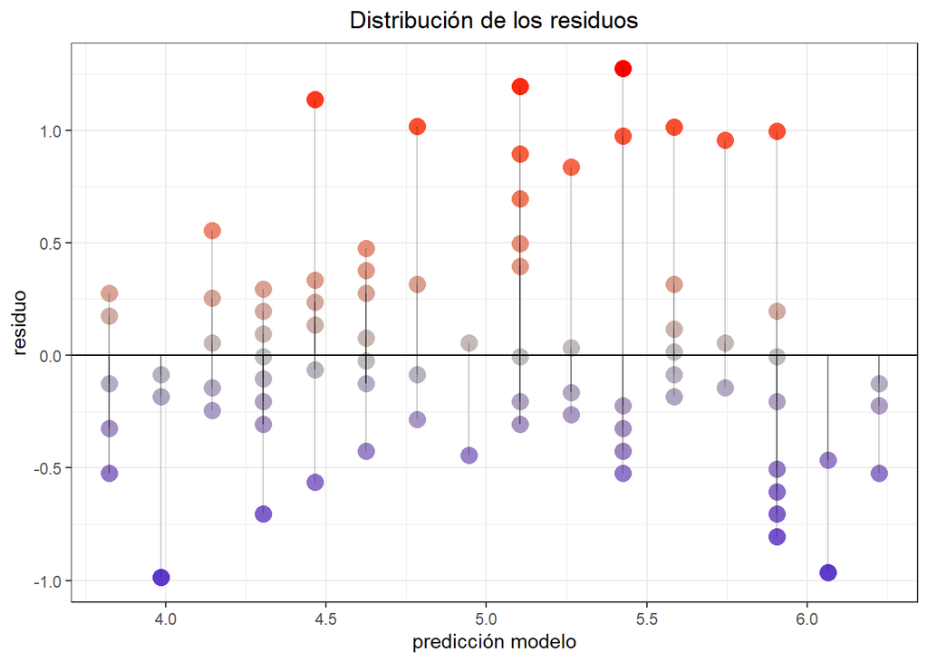

```r
ggplot(data = iris_no_setosa, aes(x = prediccion, y = residuos)) +
  geom_point(aes(color = residuos), size=4) +
  scale_color_gradient2(low = "blue3", mid = "grey", high = "red") +
  geom_hline(yintercept = 0) +
  geom_segment(aes(xend = prediccion, yend = 0), alpha = 0.2) +
  labs(title = "Distribución de los residuos", x = "predicción modelo",
       y = "residuo") +
  theme_bw() +
  theme(plot.title = element_text(hjust = 0.5), legend.position = "none")
```

No se observa ningun patron en particular, los residuos se distribuyen de forma aleatoria entorno al 0 por lo que se acepta la linealidad.

2. Distribución Normal de los residuos: Los residuos se tiene que distribuir de forma normal, con media igual a 0.

Los residuos se deben distribuir de forma normal con media 0. Para comprobarlo se recurre a histogramas, a los cuantiles normales o a un test de contraste de normalidad.

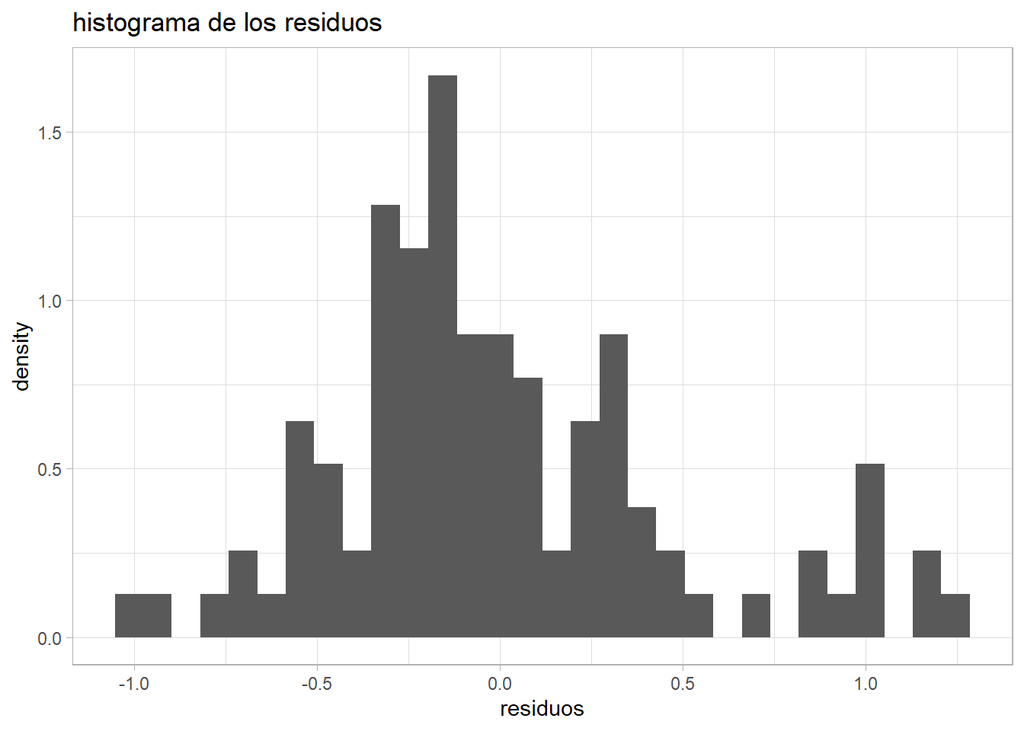

```r
ggplot(data = iris_no_setosa, aes(x = residuos)) +
  geom_histogram(aes(y = ..density..)) +
  labs(title = "histograma de los residuos") +
  theme_light()
```

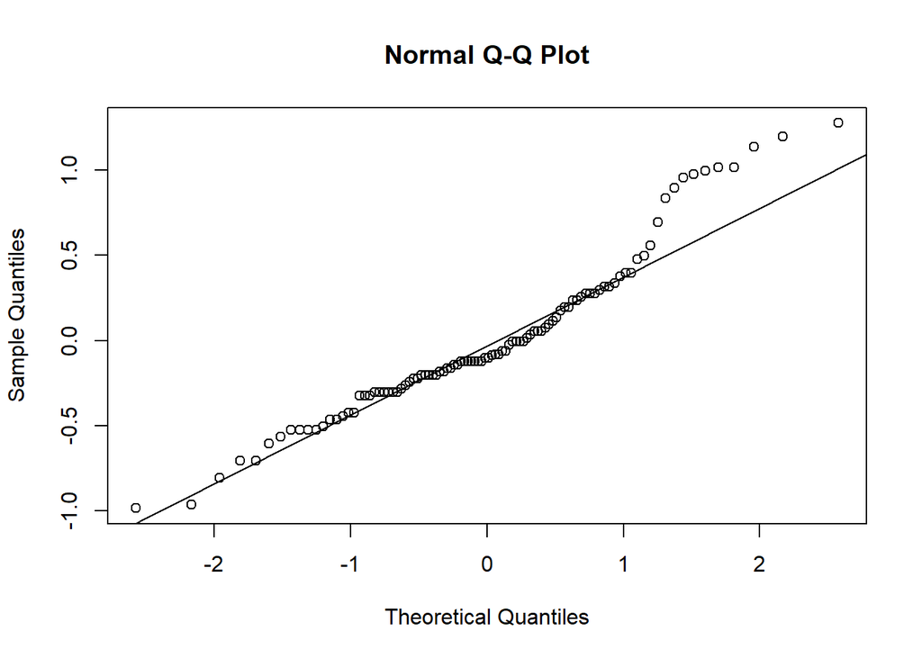

```r
qqnorm(lm_pet_sep$residuals)
qqline(lm_pet_sep$residuals)
```

```r
shapiro.test(lm_pet_sep$residuals)
```

```
##
##  Shapiro-Wilk normality test
##
## data:  lm_pet_sep$residuals
## W = 0.94518, p-value = 0.0004051
```

Tanto la representación gráfica como el contraste de hipótesis revelan que los residuos no siguen una distribución normal.

3. Varianza constante de los residuos (Homocedasticidad):

La variabilidad de los residuos debe de ser constante a lo largo del eje X. Un patrón cónico es indicativo de falta de homogeneidad en la varianza.

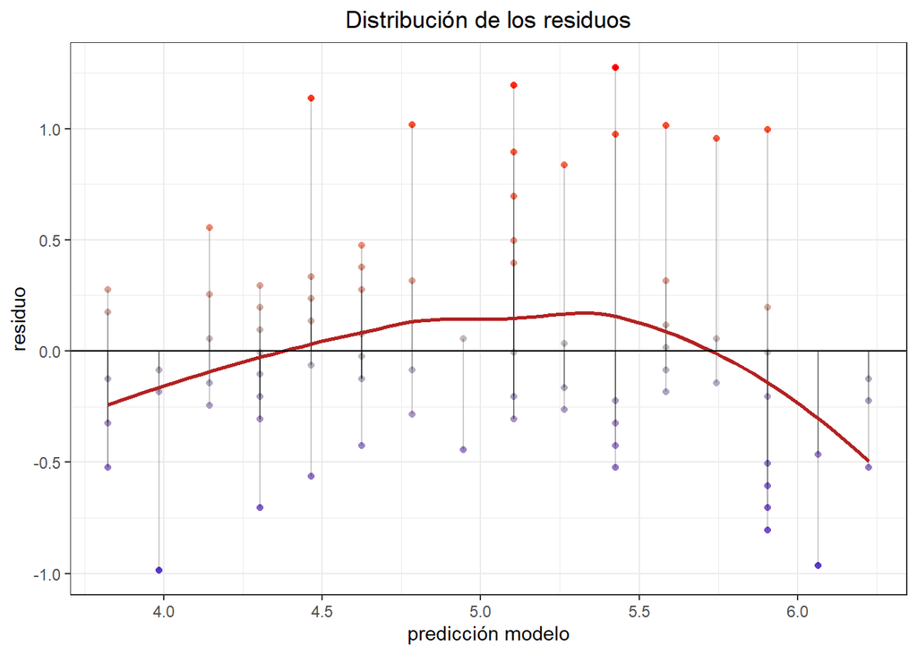

```r
ggplot(data = iris_no_setosa, aes(x = prediccion, y = residuos)) +
  geom_point(aes(color = residuos)) +
  scale_color_gradient2(low = "blue3", mid = "grey", high = "red") +
  geom_segment(aes(xend = prediccion, yend = 0), alpha = 0.2) +
  geom_smooth(se = FALSE, color = "firebrick") +
  labs(title = "Distribución de los residuos", x = "predicción modelo",
       y = "residuo") +
  geom_hline(yintercept = 0) +
  theme_bw() +
  theme(plot.title = element_text(hjust = 0.5), legend.position = "none")
```

Parece que existe un patron en la varianza, pongamolo a prueba con el analisis de Breush-Pagan

```r
# Test de Breush-Pagan
bptest(lm_pet_sep)
```

```
##
##  studentized Breusch-Pagan test
##
## data:  lm_pet_sep
## BP = 4.7947, df = 1, p-value = 0.02855
```

Se confirma que existe un patron en la varainza tanto en la representación gráfica como el contraste de hipótesis.

4. Valores atípicos y de alta influencia: Hay que estudiar con detenimiento los valores atípicos o extremos ya que pueden generar una falsa correlación que realmente no existe, u ocultar una existente.

a.El valor real se aleja mucho del valor predicho, por lo que su residuo es excesivamente grande. En una representación bidimensional se corresponde con desviaciones en el eje Y.

2. Observación influyente: Observación que influye sustancialmente en el modelo, su exclusión afecta al ajuste. No todos los outliers tienen por qué ser influyentes.
3. Observación con alto leverage: Observación con un valor extremo para alguno de los predictores. En una representación bidimensional se corresponde con desviaciones en el eje X. Son potencialmente puntos influyentes.

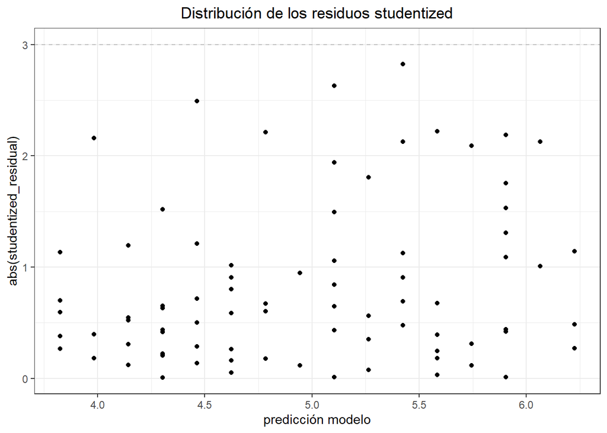

```r
iris_no_setosa$studentized_residual <- rstudent(lm_pet_sep)
ggplot(data = iris_no_setosa, aes(x = prediccion, y = abs(studentized_residual))) +
  geom_hline(yintercept = 3, color = "grey", linetype = "dashed") +
  # se identifican en rojo observaciones con residuos studentized absolutos > 3
  geom_point(aes(color = ifelse(abs(studentized_residual) > 3, 'red', 'black'))) +
  scale_color_identity() +
  #se muestra la specie al que pertenece la observación atípica
  geom_text_repel(data = filter(iris_no_setosa, abs(studentized_residual) > 3),
                  aes(label = Species)) +
  labs(title="Distribución de los residuos studentized", x="predicción modelo") +
  theme_bw() +
  theme(plot.title = element_text(hjust = 0.5), legend.position = "none")
```

Por fortuna no hay valores extremos. En caso de que existiesen y los quisieras encontrar puedes utilizar el código

```r
iris_no_setosa %>% filter(abs(studentized_residual) > 3)
```

```
## [1] Sepal.Length         Sepal.Width          Petal.Length
## [4] Petal.Width          Species              prediccion
## [7] residuos             studentized_residual
## <0 rows> (or 0-length row.names)
```

Si quisieras detectar su ubicación en la base de datos

```r
which(abs(iris_no_setosa$studentized_residual) > 3)
```

```
## integer(0)
```

El hecho de que un valor sea atípico o con alto grado de leverage no implica que sea influyente en el conjunto del modelo. Sin embargo, si un valor es influyente, suele ser o atípico o de alto leverage. En R se dispone de la función outlierTest() del paquete car y de las funciones influence.measures(), influencePlot() y hatvalues() para identificar las observaciones más influyentes en el modelo.

```r
summary(influence.measures(model = lm_pet_sep))
```

```
## Potentially influential observations of
##   lm(formula = Petal.Length ~ Petal.Width, data = iris_no_setosa) :
##
##    dfb.1_ dfb.Pt.W dffit   cov.r   cook.d hat
## 51  0.08  -0.10    -0.11    1.07_*  0.01   0.05
## 58 -0.01   0.08     0.28    0.90_*  0.04   0.01
## 60  0.05  -0.05    -0.06    1.07_*  0.00   0.05
## 65  0.31  -0.37    -0.43_*  0.97    0.09   0.04
## 73 -0.14   0.22     0.36    0.89_*  0.06   0.02
## 80  0.09  -0.04     0.23    0.93_*  0.02   0.01
## 85  0.22  -0.16     0.30    0.91_*  0.04   0.01
```

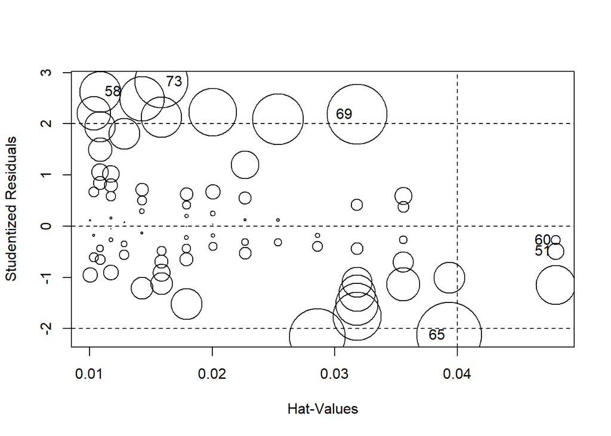

```
##       StudRes        Hat       CookD
## 51 -0.4869220 0.04801147 0.006025544
## 58  2.6284603 0.01086080 0.035772647
## 60 -0.2699086 0.04801147 0.001854577
## 65 -2.1270176 0.03934522 0.089432065
## 69  2.1893838 0.03179864 0.075781483
## 73  2.8258964 0.01587693 0.060130587
```

```r
influencePlot(model = lm_pet_sep)
```

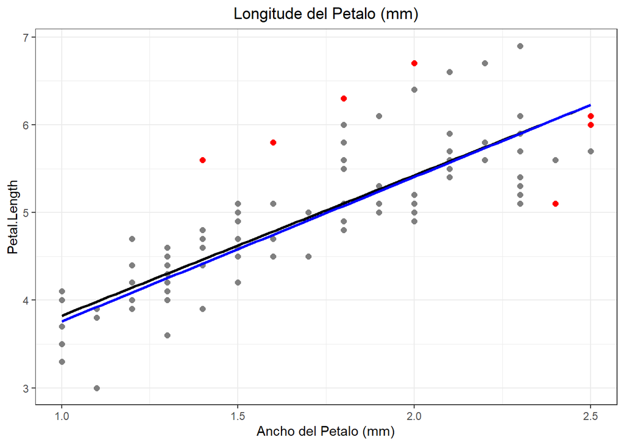

```r
ggplot(data = iris_no_setosa, mapping = aes(x = Petal.Width, y = Petal.Length)) +
  geom_point(color = "grey50", size = 2) +
  geom_smooth(method = "lm", se = FALSE, color = "black") +
  #se resalta el valor excluido
  geom_point(data = iris_no_setosa[c(51,58,60,65,73,80,85),], color = "red", size = 2) +
  #se añade la nueva recta de mínimos cuadrados
  geom_smooth(data = iris_no_setosa[-c(51,58,60,65,73,80,85),], method = "lm", se = FALSE, color = "blue") +
  labs(title  =  'Longitude del Petalo (mm)', x  =  'Ancho del Petalo (mm)') +
  theme_bw() +
  theme(plot.title = element_text(hjust = 0.5), legend.position = "none")
```

La eliminación del valor identificado como influyente levemente cambia la recta de mínimos cuadrados. Para conocer con exactitud el resultado de excluir la observación se comparan las pendientes de ambos modelos.

```r
lm(formula = Petal.Length ~ Petal.Width, data = iris_no_setosa)$coefficients
```

```
## (Intercept) Petal.Width
##    2.223972    1.600255
```

```r
lm(formula = Petal.Length ~ Petal.Width, data = iris_no_setosa[-c(51,58,60,65,73,80,85),])$coefficients
```

```
## (Intercept) Petal.Width
##    2.112032    1.646552
```

5. Independencia, autocorrelación: Las observaciones deben ser independientes unas de otras. Esto es importante tenerlo en cuenta cuando se trata de mediciones temporales.

Cuando se trabaja con intervalos de tiempo, es muy importante comprobar que no existe aoutocorrelación de los residuos, es decir que son independientes. Esto puede hacerse detectando visualmente patrones en la distribución de los residuos cuando se ordenan según se han registrado o con el test de Durbin-Watson dwt() del paquete Car.

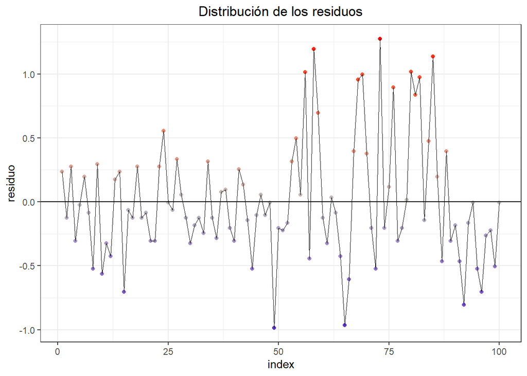

```r
ggplot(data = iris_no_setosa, aes(x = seq_along(residuos), y = residuos)) +
  geom_point(aes(color = residuos)) +
  scale_color_gradient2(low = "blue3", mid = "grey", high = "red") +
  geom_line(size = 0.3) +
  labs(title = "Distribución de los residuos", x = "index", y = "residuo") +
  geom_hline(yintercept = 0) +
  theme_bw() +
  theme(plot.title = element_text(hjust = 0.5), legend.position = "none")
```

El método alternativo es ocupar la función que viene incorporada por defecto en R y generar un conjunto de gráficos con la misma informacion

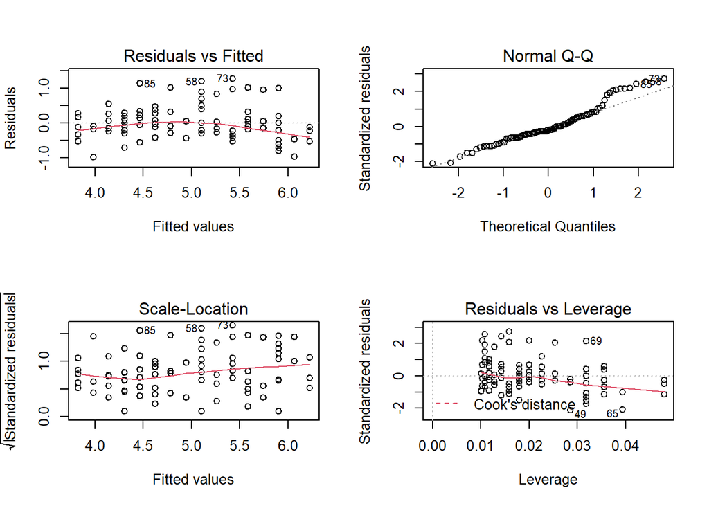

```r
par(mfrow = c(2,2))
plot(lm_pet_sep)
```

#### Conclusión

El modelo se adhiere a los supuestos de linearidad (1), carencia de valores atipicos (4) independencia (5), pero no cumple los supuestos de normalidad en los residuos (2) y homocedasticidad (3). Por lo tanto se debe ser cuidadoso alinterpretar el model si es que se acepta, considerar válido un modelo de regresión lineal por mínimos cuadrados. El valor de probabilidad (p-value) indica que el ajuste es significativo, se puede aceptar el modelo lineal. El valor de R2 es modesto, por lo que se podria considerar que el ancho del pétalo es un buen predictor de la longitud del pétalo.

#### PARA ANALIZAR…..

Cuando los modelos no cumplen los supuestos, se pueden realizar algunos pasos para mejorar este proceso. Entre ellos: transformar las variables, incluir mas variables explicativas o ajustar la variable respuesta a otro tipo de distribución. Estos aspectos no seran explorados en este curso, pero hay bastante informacion sobre ello disponible en linea. Tambien, en cursos mas avanzados de la Fundacion Naturaleza El Salvador.

### ANALISIS DE COVARIANZA (ANCOVA)

Hasta ahora hemos visto como analizar variables respuesta, en relación a variables explicativas categoricas (llamadas tratamientos o factores) en el Analisis de varianza y hemos ejecutado el mismo proceso para analisis que involucran variables explicativas continuas, como en el caso de la regresión lineal simple.

Si aumentamos la complejidad de estos fenomenos podriamos predecir la misma variable, combinando dos variables explicativas, una categórica y otra continua: ANCOVA.

El Análisis de la Covarianza tiene las siguientes características:

1.Tiene en cuenta la influencia de las variables concomitantes sobre la variable observable o respuesta. 2.La variable concomitante es siempre cuantitativa. Cada réplica debe tener asociado un valor de la variable concomitante. 3.Las variables concomitantes no se utilizan como variables de referencia para contrastar hipótesis. Lo que se pretende es eliminar su influencia sobre la variable observable. 4.La varianza del diseño queda reducida al introducir una variable concomitante. Una consecuencia es el aumento de la precisión en las conclusiones. 5.En general se logra simplificar el diseño, reduciendo el número de factores, lo que redundará en un número menor de réplicas. La interpretación del diseño es más fácil cuando los factores sólo influyen en la variable respuesta y no en las variables concomitantes.

### Escenario de nuestra investigacion

Los datos colectados en la matriz iris indican que existe una relacion entre la longitud del sepalo y el ancho del sepalo, sin embargo, como biologos acusiosos sospechamos que esta relación podria ser influenciada por la especie en estudio. Por ello, ahora queremos reconstruir nuestros análisis previos considerando que: la longitud de los sépalos es diferente entre las especies y estas diferencias existen cuando se controla la influencia de ancho de los sépalos.

##### Supuestos del Analisis de covarianza (ANCOVA)

Podemos ver al ANCOVA como un ANOVA o ANDEVA con una variable continua adicional o por otra parte, como una regresion lineal con una variable categorica incluida. No es sorpresa que los supuestos para este analisis sean muy similares a los requeridos por ANOVA y la Regresion Lineal Simple:

1. Linealidad: La relación entre ambas variables debe ser lineal.
2. Distribución Normal de los residuos: Los residuos se tiene que distribuir de forma normal, con media igual a 0.
3. Varianza de residuos constante (homocedasticidad): La varianza de los residuos ha de ser aproximadamente constante a lo largo del eje x
4. Valores atípicos y de alta influencia: Hay que estudiar con detenimiento los valores atípicos o extremos ya que pueden generar una falsa correlación que realmente no existe, u ocultar una existente.
5. Independencia, Autocorrelación: Las observaciones deben ser independientes unas de otras. Esto es importante tenerlo en cuenta cuando se trata de mediciones temporales.

El unico supuesto que es adicional es:

6. Homogeneidad de pendientes. Este supuesto requiere que no haya una interación significativa entre la covariables y la variable de agrupación o variable categórica.

##Pongamos a prueba los supuestos graficamente

##### 1. Linealidad: La relación entre ambas variables debe ser lineal.

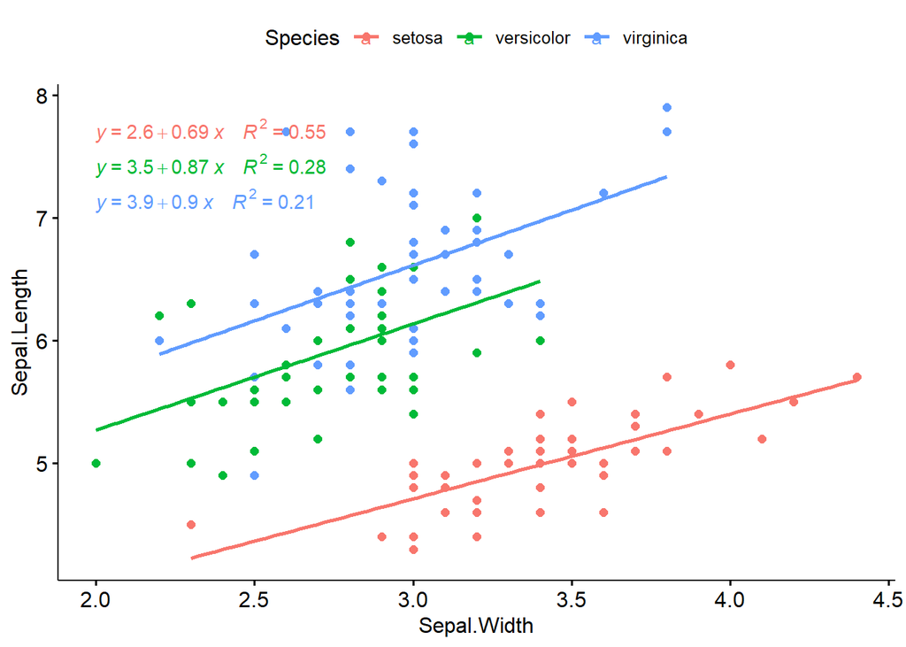

```r
ggscatter(
  iris, x = "Sepal.Width", y ="Sepal.Length" ,
  color = "Species", add = "reg.line"
  )+
  stat_regline_equation(
    aes(label =  paste(..eq.label.., ..rr.label.., sep = "~~~~"), color = Species)
    )
```

Podemos detectar que la relación entre la variable de respuesta y las variables de predicción tienen una relación lineal, en cada una de las species.

##### 2. Distribución Normal de los residuos: Los residuos se tiene que distribuir de forma normal, con media igual a 0. Como mencionamos anteriomente, se requiere realizar un modelo antes de verificar los supuestos.

```r
# AJusta el model y recuerda incluir la covariable primero.
model <- lm(Sepal.Length ~ Species*Sepal.Width, data = iris)
# Invesctiona los datos diagnosticos del modelo.
metricas.modelo <- augment(model) %>%
  select(-.hat, -.sigma, -.fitted,) # Remove details
head(metricas.modelo, 3)
```

```
## # A tibble: 3 x 6
##   Sepal.Length Species Sepal.Width  .resid .std.resid   .cooksd
##          <dbl> <fct>         <dbl>   <dbl>      <dbl>     <dbl>
## 1          5.1 setosa          3.5  0.0443      0.102 0.0000365
## 2          4.9 setosa          3    0.190       0.441 0.00157
## 3          4.7 setosa          3.2 -0.149      -0.343 0.000551
```

```r
# Assess normality of residuals using shapiro wilk test
shapiro_test(metricas.modelo$.resid)
```

```
## # A tibble: 1 x 3
##   variable               statistic p.value
##   <chr>                      <dbl>   <dbl>
## 1 metricas.modelo$.resid     0.980  0.0247
```

No podemos asumir normalidad en los residuales, debido a que la prueba arroja on valor inferior a 0.05

##### 3. Varianza de residuos constante (homocedasticidad): La varianza de los residuos ha de ser aproximadamente constante a lo largo del eje x

```r
metricas.modelo %>% levene_test(.resid ~ Species)
```

```
## # A tibble: 1 x 4
##     df1   df2 statistic        p
##   <int> <int>     <dbl>    <dbl>
## 1     2   147      9.48 0.000134
```

La prueba de Levene es significativa (p < 0.05), NO podemos asumir que las varianzas son homogeneas.

##### 4. Valores atípicos y de alta influencia: Hay que estudiar con detenimiento los valores atípicos o extremos ya que pueden generar una falsa correlación que realmente no existe, u ocultar una existente.

```r
metricas.modelo %>%
  filter(abs(.std.resid) > 3) %>%
  as.data.frame()
```

```
##   Sepal.Length   Species Sepal.Width   .resid .std.resid   .cooksd
## 1          7.7 virginica         2.6 1.449174   3.376542 0.0946485
```

Parece que existe una observacion que puede ser atipica. Sin embargo, se mantendra en el analisis debido a que en la representacion grafico no parece ser tan extrema.

##### 5. Independencia, Autocorrelación: Las observaciones deben ser independientes unas de otras. Esto es importante tenerlo en cuenta cuando se trata de mediciones temporales.

##### 6. Homogeneidad de pendientes. Este supuesto requiere que NO haya una interacion significativa entre la covariables y la variable de agrupacion o variable categorica.

```r
iris %>% anova_test(Sepal.Length ~ Species*Sepal.Width)
```

```
## ANOVA Table (type II tests)
##
##                Effect DFn DFd       F        p p<.05   ges
## 1             Species   2 144 188.109 6.87e-41     * 0.723
## 2         Sepal.Width   1 144  56.638 5.22e-12     * 0.282
## 3 Species:Sepal.Width   2 144   0.406 6.67e-01       0.006
```

### Ejecutando el ANCOVA

El orden de las variables es importante en ANCOVA, primero es necesario remover la covariable de la cual queremos controlar el efecto y luego indicamos nuestra vairable de interes. Para nuestro caso:

```r
res.ancova <- iris %>% anova_test( Sepal.Length ~ Sepal.Width + Species)
get_anova_table(res.ancova)
```

```
## ANOVA Table (type II tests)
##
##        Effect DFn DFd       F        p p<.05   ges
## 1 Sepal.Width   1 146  57.102 4.19e-12     * 0.281
## 2     Species   2 146 189.651 2.56e-41     * 0.722
```

### Post Hoc Analisis

Para indentificar los grupos que son diferentes podemos recurrir a la comparacion multiple utilizando el factor de corrección de Bonferrani.

```r
# Comparación por pares
pwc <- iris %>%
  emmeans_test(
    Sepal.Length ~ Species, covariate = Sepal.Width,
    p.adjust.method = "bonferroni"
    )
pwc
```

```
## # A tibble: 3 x 9
##   term     .y.     group1  group2    df statistic        p    p.adj p.adj.signif
## * <chr>    <chr>   <chr>   <chr>  <dbl>     <dbl>    <dbl>    <dbl> <chr>
## 1 Sepal.W~ Sepal.~ setosa  versi~   146    -13.0  3.48e-26 1.04e-25 ****
## 2 Sepal.W~ Sepal.~ setosa  virgi~   146    -19.5  2.09e-42 6.28e-42 ****
## 3 Sepal.W~ Sepal.~ versic~ virgi~   146     -5.41 2.54e- 7 7.61e- 7 ****
```

Podemos obtener los promedio de cada grupo para analizar con mas detalle estas diferencias.

```r
get_emmeans(pwc)
```

```
## # A tibble: 3 x 8
##   Sepal.Width Species    emmean     se    df conf.low conf.high method
##         <dbl> <fct>       <dbl>  <dbl> <dbl>    <dbl>     <dbl> <chr>
## 1        3.06 setosa       4.71 0.0734   146     4.56      4.85 Emmeans test
## 2        3.06 versicolor   6.17 0.0691   146     6.03      6.30 Emmeans test
## 3        3.06 virginica    6.65 0.0626   146     6.53      6.78 Emmeans test
```

#### El gráfico de ANCOVA

Existen muchas formas de presentar estos resultados. Esta es solo una opción.

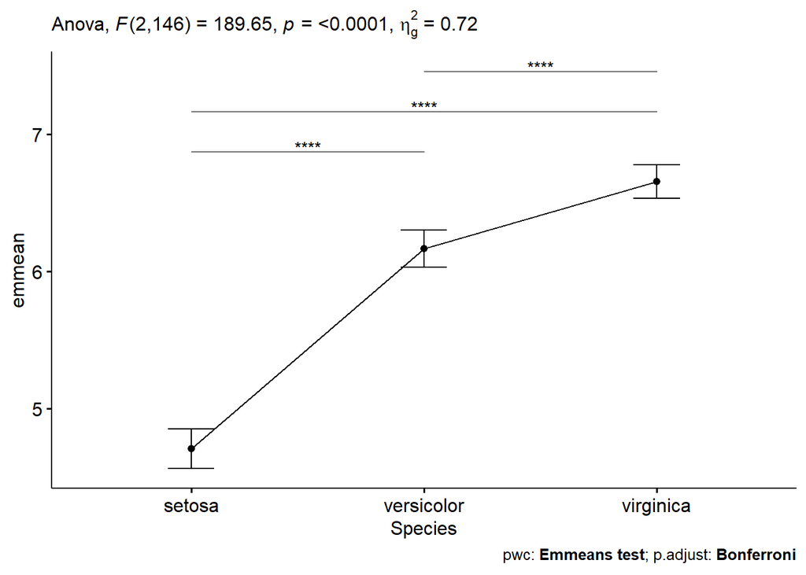

```r
pwc <- pwc %>% add_xy_position(x = "Species", fun = "mean_se")
ggline(get_emmeans(pwc), x = "Species", y = "emmean") +
  geom_errorbar(aes(ymin = conf.low, ymax = conf.high), width = 0.2) +
  stat_pvalue_manual(pwc, hide.ns = TRUE, tip.length = FALSE) +
  labs(
    subtitle = get_test_label(res.ancova, detailed = TRUE),
    caption = get_pwc_label(pwc)
  )
```

REFERENCIAS

Amat Rodrigo, J. 2016. ANOVA análisis de varianza para comparar múltiples medias. https://rpubs.com/Joaquin_AR/219148

Logan, M. 2010. Biostatistical Design and Analysis Using R: A Practical Guide.546 pp. DOI: 10.1002/9781444319620, ISBN: 9781405190084

Logan, M. 2021. Single Factor Anova. https://www.flutterbys.com.au/stats/tut/tut7.4a.html

Logan, M. 2021. Analysis of Covariance https://www.flutterbys.com.au/stats/tut/tut7.5a.html

Logan, M. 2021. Simple Linear Regression. https://www.flutterbys.com.au/stats/tut/tut7.2a.html

Quinn, G., & Keough, M. 2002. Graphical exploration of data. In Experimental Design and Data Analysis for Biologists (pp. 58-71). Cambridge: Cambridge University Press. doi:10.1017/CBO9780511806384.005

Quinn, G., & Keough, M. 2002. Correlation and regression. In Experimental Design and Data Analysis for Biologists (pp. 72-110). Cambridge: Cambridge University Press. doi:10.1017/CBO9780511806384.006

Quinn, G., & Keough, M. 2002. Comparing groups or treatments – analysis of variance. In Experimental Design and Data Analysis for Biologists (pp. 173-207). Cambridge: Cambridge University Press. doi:10.1017/CBO9780511806384.009

Quinn, G., & Keough, M. 2002. Analyses of covariance. In Experimental Design and Data Analysis for Biologists (pp. 339-358). Cambridge: Cambridge University Press. doi:10.1017/CBO9780511806384.013

Whitlock M. C. Schluter D. 2009. The analysis of biological data. Greenwood Village, Colorado. Roberts and Company Publishers. 700p